# ANCOVA test for debate (engajamento no debate)

Geiser C. Challco geiser@alumni.usp.br

- Descriptive Statistics of Initial Data
- Checking of Assumptions
  - Assumption: Normality distribution of data
  - Assumption: Homogeneity of data distribution
- Computation of ANCOVA test and Pairwise Comparison
  - ANCOVA tests for one factor
  - ANCOVA tests for two factors
  - ANCOVA tests for grupo=“stari+WG”
  - Pairwise comparisons for one factor
    - factor: **grupo**
    - factor: **genero**
    - factor: **idade**
    - factor: **zona.participante**
    - factor: **escola**
    - factor: **zona.escola**
  - Pairwise comparisons for two factors
    - factores: **grupo:genero**
    - factores: **grupo:idade**
    - factores: **grupo:zona.participante**
    - factores: **grupo:escola**
    - factores: **grupo:zona.escola**
  - Pairwise comparisons for grupo=“Experimental”
    - factores: **grupo=“Experimental”:monitor**
    - factores: **grupo=“Experimental”:monitor.genero**
    - factores: **grupo=“Experimental”:monitor.area**
    - factores: **grupo=“Experimental”:monitor.formacao**
    - factores: **grupo=“Experimental”:monitor.experiencia**

**NOTE**

- Teste ANCOVA para determinar se houve diferenças significativas em referência ao engajamento no debate (medido como estado de fluxo).
- ANCOVA test to determine whether there were significant differences in reference to engagement in debate (measured as flow state).

# Descriptive Statistics of Initial Data

| grupo | genero | idade | zona.participante | escola | zona.escola | variable | n | mean | median | min | max | sd | se | ci | iqr |
| --- | --- | --- | --- | --- | --- | --- | --- | --- | --- | --- | --- | --- | --- | --- | --- |
| Controle | F |  |  |  |  | fss.debate | 6 | 3.370 | 3.222 | 2.889 | 4.333 | 0.552 | 0.225 | 0.579 | 0.583 |
| Controle | M |  |  |  |  | fss.debate | 9 | 2.923 | 2.889 | 2.222 | 3.667 | 0.421 | 0.140 | 0.323 | 0.472 |
| stari+WG | F |  |  |  |  | fss.debate | 4 | 3.326 | 3.000 | 2.750 | 4.556 | 0.848 | 0.424 | 1.349 | 0.785 |
| stari+WG | M |  |  |  |  | fss.debate | 12 | 3.382 | 3.389 | 2.778 | 4.222 | 0.462 | 0.133 | 0.293 | 0.785 |
| Controle | F |  |  |  |  | dfs.debate | 6 | 3.130 | 3.167 | 2.556 | 3.556 | 0.381 | 0.156 | 0.400 | 0.500 |
| Controle | M |  |  |  |  | dfs.debate | 9 | 2.975 | 3.111 | 2.111 | 3.444 | 0.451 | 0.150 | 0.346 | 0.333 |
| stari+WG | F |  |  |  |  | dfs.debate | 4 | 2.889 | 2.944 | 1.889 | 3.778 | 0.775 | 0.388 | 1.233 | 0.556 |
| stari+WG | M |  |  |  |  | dfs.debate | 12 | 3.040 | 2.944 | 2.556 | 4.000 | 0.451 | 0.130 | 0.286 | 0.413 |
| Controle |  | 10y |  |  |  | fss.debate | 4 | 3.528 | 3.444 | 2.889 | 4.333 | 0.624 | 0.312 | 0.994 | 0.694 |
| Controle |  | 11y |  |  |  | fss.debate | 8 | 3.066 | 3.111 | 2.556 | 3.667 | 0.344 | 0.122 | 0.288 | 0.368 |
| Controle |  | 12y |  |  |  | fss.debate | 1 | 2.778 | 2.778 | 2.778 | 2.778 |  |  |  | 0.000 |
| Controle |  | 13y |  |  |  | fss.debate | 1 | 2.889 | 2.889 | 2.889 | 2.889 |  |  |  | 0.000 |
| Controle |  | 15y |  |  |  | fss.debate | 1 | 2.222 | 2.222 | 2.222 | 2.222 |  |  |  | 0.000 |
| stari+WG |  | 10y |  |  |  | fss.debate | 2 | 4.056 | 4.056 | 3.889 | 4.222 | 0.236 | 0.167 | 2.118 | 0.167 |
| stari+WG |  | 11y |  |  |  | fss.debate | 9 | 3.154 | 3.111 | 2.750 | 3.778 | 0.403 | 0.134 | 0.310 | 0.556 |
| stari+WG |  | 12y |  |  |  | fss.debate | 2 | 4.000 | 4.000 | 3.444 | 4.556 | 0.786 | 0.556 | 7.059 | 0.556 |
| stari+WG |  | 13y |  |  |  | fss.debate | 3 | 3.130 | 3.000 | 2.889 | 3.500 | 0.326 | 0.188 | 0.809 | 0.306 |
| Controle |  | 10y |  |  |  | dfs.debate | 4 | 3.222 | 3.222 | 2.889 | 3.556 | 0.327 | 0.164 | 0.520 | 0.500 |
| Controle |  | 11y |  |  |  | dfs.debate | 8 | 3.139 | 3.222 | 2.444 | 3.444 | 0.335 | 0.118 | 0.280 | 0.306 |
| Controle |  | 12y |  |  |  | dfs.debate | 1 | 2.889 | 2.889 | 2.889 | 2.889 |  |  |  | 0.000 |
| Controle |  | 13y |  |  |  | dfs.debate | 1 | 2.556 | 2.556 | 2.556 | 2.556 |  |  |  | 0.000 |
| Controle |  | 15y |  |  |  | dfs.debate | 1 | 2.111 | 2.111 | 2.111 | 2.111 |  |  |  | 0.000 |
| stari+WG |  | 10y |  |  |  | dfs.debate | 2 | 2.778 | 2.778 | 2.667 | 2.889 | 0.157 | 0.111 | 1.412 | 0.111 |
| stari+WG |  | 11y |  |  |  | dfs.debate | 9 | 2.892 | 3.000 | 1.889 | 3.778 | 0.502 | 0.167 | 0.386 | 0.222 |
| stari+WG |  | 12y |  |  |  | dfs.debate | 2 | 3.500 | 3.500 | 3.222 | 3.778 | 0.393 | 0.278 | 3.530 | 0.278 |
| stari+WG |  | 13y |  |  |  | dfs.debate | 3 | 3.148 | 2.889 | 2.556 | 4.000 | 0.756 | 0.437 | 1.879 | 0.722 |
| Controle |  |  | Urbana |  |  | fss.debate | 9 | 3.136 | 3.222 | 2.222 | 4.333 | 0.552 | 0.184 | 0.424 | 0.333 |
| Controle |  |  | Rural |  |  | fss.debate | 2 | 2.722 | 2.722 | 2.556 | 2.889 | 0.236 | 0.167 | 2.118 | 0.167 |
| Controle |  |  |  |  |  | fss.debate | 4 | 3.215 | 3.222 | 2.750 | 3.667 | 0.521 | 0.261 | 0.830 | 0.896 |
| stari+WG |  |  | Urbana |  |  | fss.debate | 6 | 3.574 | 3.625 | 2.750 | 4.556 | 0.622 | 0.254 | 0.653 | 0.563 |
| stari+WG |  |  | Rural |  |  | fss.debate | 5 | 3.289 | 3.222 | 2.778 | 4.222 | 0.570 | 0.255 | 0.708 | 0.444 |
| stari+WG |  |  |  |  |  | fss.debate | 5 | 3.200 | 3.000 | 2.778 | 3.889 | 0.461 | 0.206 | 0.572 | 0.556 |
| Controle |  |  | Urbana |  |  | dfs.debate | 9 | 3.012 | 3.000 | 2.111 | 3.556 | 0.492 | 0.164 | 0.378 | 0.556 |
| Controle |  |  | Rural |  |  | dfs.debate | 2 | 2.833 | 2.833 | 2.556 | 3.111 | 0.393 | 0.278 | 3.530 | 0.278 |
| Controle |  |  |  |  |  | dfs.debate | 4 | 3.194 | 3.222 | 2.889 | 3.444 | 0.229 | 0.115 | 0.364 | 0.139 |
| stari+WG |  |  | Urbana |  |  | dfs.debate | 6 | 3.352 | 3.389 | 2.556 | 4.000 | 0.577 | 0.236 | 0.606 | 0.778 |
| stari+WG |  |  | Rural |  |  | dfs.debate | 5 | 2.940 | 2.889 | 2.778 | 3.143 | 0.138 | 0.062 | 0.171 | 0.111 |
| stari+WG |  |  |  |  |  | dfs.debate | 5 | 2.644 | 2.667 | 1.889 | 3.222 | 0.493 | 0.221 | 0.612 | 0.333 |
| Controle |  |  |  | E1 |  | fss.debate | 6 | 3.093 | 2.944 | 2.222 | 4.333 | 0.694 | 0.283 | 0.728 | 0.278 |
| Controle |  |  |  | E2 |  | fss.debate | 1 | 2.778 | 2.778 | 2.778 | 2.778 |  |  |  | 0.000 |
| Controle |  |  |  | E5 |  | fss.debate | 6 | 2.977 | 3.056 | 2.556 | 3.222 | 0.289 | 0.118 | 0.303 | 0.437 |
| Controle |  |  |  | E6 |  | fss.debate | 2 | 3.667 | 3.667 | 3.667 | 3.667 | 0.000 | 0.000 | 0.000 | 0.000 |
| stari+WG |  |  |  | E2 |  | fss.debate | 2 | 3.167 | 3.167 | 3.000 | 3.333 | 0.236 | 0.167 | 2.118 | 0.167 |
| stari+WG |  |  |  | E4 |  | fss.debate | 5 | 3.606 | 3.750 | 2.778 | 4.222 | 0.531 | 0.237 | 0.659 | 0.278 |
| stari+WG |  |  |  | E5 |  | fss.debate | 7 | 3.171 | 2.889 | 2.750 | 4.556 | 0.634 | 0.240 | 0.587 | 0.333 |
| stari+WG |  |  |  | E6 |  | fss.debate | 2 | 3.667 | 3.667 | 3.444 | 3.889 | 0.314 | 0.222 | 2.824 | 0.222 |
| Controle |  |  |  | E1 |  | dfs.debate | 6 | 2.907 | 2.944 | 2.111 | 3.556 | 0.560 | 0.228 | 0.587 | 0.778 |
| Controle |  |  |  | E2 |  | dfs.debate | 1 | 2.889 | 2.889 | 2.889 | 2.889 |  |  |  | 0.000 |
| Controle |  |  |  | E5 |  | dfs.debate | 6 | 3.093 | 3.167 | 2.556 | 3.444 | 0.325 | 0.133 | 0.341 | 0.361 |
| Controle |  |  |  | E6 |  | dfs.debate | 2 | 3.333 | 3.333 | 3.222 | 3.444 | 0.157 | 0.111 | 1.412 | 0.111 |
| stari+WG |  |  |  | E2 |  | dfs.debate | 2 | 3.016 | 3.016 | 2.889 | 3.143 | 0.180 | 0.127 | 1.613 | 0.127 |
| stari+WG |  |  |  | E4 |  | dfs.debate | 5 | 3.333 | 3.000 | 2.889 | 4.000 | 0.515 | 0.230 | 0.640 | 0.778 |
| stari+WG |  |  |  | E5 |  | dfs.debate | 7 | 2.778 | 2.778 | 1.889 | 3.778 | 0.570 | 0.216 | 0.527 | 0.389 |
| stari+WG |  |  |  | E6 |  | dfs.debate | 2 | 2.944 | 2.944 | 2.667 | 3.222 | 0.393 | 0.278 | 3.530 | 0.278 |
| Controle |  |  |  |  | Urbana | fss.debate | 13 | 3.015 | 2.889 | 2.222 | 4.333 | 0.494 | 0.137 | 0.298 | 0.444 |
| Controle |  |  |  |  | Rural | fss.debate | 2 | 3.667 | 3.667 | 3.667 | 3.667 | 0.000 | 0.000 | 0.000 | 0.000 |
| stari+WG |  |  |  |  | Urbana | fss.debate | 9 | 3.170 | 3.000 | 2.750 | 4.556 | 0.556 | 0.185 | 0.427 | 0.333 |
| stari+WG |  |  |  |  | Rural | fss.debate | 7 | 3.623 | 3.750 | 2.778 | 4.222 | 0.453 | 0.171 | 0.419 | 0.361 |
| Controle |  |  |  |  | Urbana | dfs.debate | 13 | 2.991 | 3.000 | 2.111 | 3.556 | 0.429 | 0.119 | 0.259 | 0.444 |
| Controle |  |  |  |  | Rural | dfs.debate | 2 | 3.333 | 3.333 | 3.222 | 3.444 | 0.157 | 0.111 | 1.412 | 0.111 |
| stari+WG |  |  |  |  | Urbana | dfs.debate | 9 | 2.831 | 2.889 | 1.889 | 3.778 | 0.509 | 0.170 | 0.391 | 0.444 |
| stari+WG |  |  |  |  | Rural | dfs.debate | 7 | 3.222 | 3.000 | 2.667 | 4.000 | 0.489 | 0.185 | 0.452 | 0.556 |

# Checking of Assumptions

## Assumption: Normality distribution of data

| var | n | skewness | kurtosis | symmetry | statistic | method | p | p.signif | normality |
| --- | --- | --- | --- | --- | --- | --- | --- | --- | --- |
| fss.debate | 31 | 0.6407821 | -0.5319450 | NO | 0.9373008 | Shapiro-Wilk | 0.0695025 | ns | YES |
| fss.debate | 31 | 0.1367057 | -0.5376001 | YES | 0.9554405 | Shapiro-Wilk | 0.2200874 | ns | YES |
| fss.debate | 22 | 0.6829606 | -0.5401767 | NO | 0.9349856 | Shapiro-Wilk | 0.1558188 | ns | YES |
| fss.debate | 31 | 0.5796651 | -0.2113149 | NO | 0.9463335 | Shapiro-Wilk | 0.1235955 | ns | YES |
| fss.debate | 31 | 0.6997563 | 0.1994279 | NO | 0.9457495 | Shapiro-Wilk | 0.1190746 | ns | YES |

## Assumption: Homogeneity of data distribution

| var | method | formula | n | DFn.df1 | DFd.df2 | statistic | p | p.signif |
| --- | --- | --- | --- | --- | --- | --- | --- | --- |
| fss.debate | Levene’s test | `.res`~`grupo`*`genero` | 31 | 3 | 27 | 0.1903504 | 0.9020438 | ns |
| fss.debate | Anova’s slopes | `.res`~`grupo`*`genero` | 31 | 3 | 23 | 1.0320000 | 0.3970000 | ns |
| fss.debate | Levene’s test | `.res`~`grupo`*`idade` | 31 | 8 | 22 | 1.0586431 | 0.4254417 | ns |
| fss.debate | Anova’s slopes | `.res`~`grupo`*`idade` | 31 | 5 | 16 | 1.4910000 | 0.2470000 | ns |
| fss.debate | Levene’s test | `.res`~`grupo`*`zona.participante` | 22 | 3 | 18 | 0.2106805 | 0.8876771 | ns |
| fss.debate | Anova’s slopes | `.res`~`grupo`*`zona.participante` | 22 | 3 | 14 | 0.4230000 | 0.7390000 | ns |
| fss.debate | Levene’s test | `.res`~`grupo`*`escola` | 31 | 7 | 23 | 1.0254910 | 0.4402882 | ns |
| fss.debate | Anova’s slopes | `.res`~`grupo`*`escola` | 31 | 6 | 16 | 0.9930000 | 0.4630000 | ns |
| fss.debate | Levene’s test | `.res`~`grupo`*`zona.escola` | 31 | 3 | 27 | 1.1335286 | 0.3531495 | ns |
| fss.debate | Anova’s slopes | `.res`~`grupo`*`zona.escola` | 31 | 3 | 23 | 1.8760000 | 0.1620000 | ns |

# Computation of ANCOVA test and Pairwise Comparison

## ANCOVA tests for one factor

|  | Effect | DFn | DFd | SSn | SSd | F | p | ges | p<.05 |
| --- | --- | --- | --- | --- | --- | --- | --- | --- | --- |
| 1 | dfs.debate | 1 | 28 | 2.718 | 5.452 | 13.958 | <0.001 | 0.333 | * |
| 2 | grupo | 1 | 28 | 0.645 | 5.452 | 3.311 | 0.08 | 0.106 |  |
| 4 | genero | 1 | 28 | 0.161 | 5.936 | 0.760 | 0.391 | 0.026 |  |
| 6 | idade | 4 | 25 | 1.838 | 4.259 | 2.698 | 0.054 | 0.301 |  |
| 8 | zona.participante | 1 | 19 | 0.000 | 4.533 | 0.001 | 0.976 | 0.000 |  |
| 10 | escola | 4 | 25 | 0.951 | 5.146 | 1.155 | 0.354 | 0.156 |  |
| 12 | zona.escola | 1 | 28 | 0.876 | 5.221 | 4.699 | 0.039 | 0.144 | * |

## ANCOVA tests for two factors

|  | Effect | DFn | DFd | SSn | SSd | F | p | ges | p<.05 |
| --- | --- | --- | --- | --- | --- | --- | --- | --- | --- |
| 1 | dfs.debate | 1 | 26 | 2.434 | 5.006 | 12.640 | 0.001 | 0.327 | * |
| 4 | grupo:genero | 1 | 26 | 0.158 | 5.006 | 0.822 | 0.373 | 0.031 |  |
| 8 | grupo:idade | 3 | 21 | 0.640 | 2.734 | 1.639 | 0.211 | 0.190 |  |
| 12 | grupo:zona.participante | 1 | 17 | 0.081 | 4.044 | 0.339 | 0.568 | 0.020 |  |
| 16 | grupo:escola | 2 | 22 | 0.018 | 4.586 | 0.043 | 0.958 | 0.004 |  |
| 20 | grupo:zona.escola | 1 | 26 | 0.061 | 4.915 | 0.324 | 0.574 | 0.012 |  |

## ANCOVA tests for grupo=“stari+WG”

|  | Effect | DFn | DFd | SSn | SSd | F | p | ges | p<.05 |
| --- | --- | --- | --- | --- | --- | --- | --- | --- | --- |
| 1 | dfs.debate | 1 | 4 | 0.028 | 1.198 | 0.094 | 0.774 | 0.023 |  |
| 2 | monitor | 5 | 4 | 1.166 | 1.198 | 0.779 | 0.613 | 0.493 |  |
| 4 | monitor.genero | 1 | 8 | 0.049 | 2.315 | 0.169 | 0.692 | 0.021 |  |
| 6 | monitor.area | 5 | 4 | 1.166 | 1.198 | 0.779 | 0.613 | 0.493 |  |
| 8 | monitor.formacao | 2 | 7 | 0.350 | 2.014 | 0.607 | 0.571 | 0.148 |  |
| 10 | monitor.experiencia | 1 | 8 | 0.001 | 2.363 | 0.003 | 0.958 | 0.000 |  |

## Pairwise comparisons for one factor

### factor: **grupo**

| var | grupo | n | M (pre) | SE (pre) | M (unadj) | SE (unadj) | M (adj) | SE (adj) |
| --- | --- | --- | --- | --- | --- | --- | --- | --- |
| fss.debate | Controle | 15 | 3.037 | 0.108 | 3.102 | 0.132 | 3.090 | 0.114 |
| fss.debate | stari+WG | 16 | 3.002 | 0.131 | 3.368 | 0.137 | 3.379 | 0.110 |

| .y. | group1 | group2 | estimate | conf.low | conf.high | se | statistic | p | p.adj | p.adj.signif |
| --- | --- | --- | --- | --- | --- | --- | --- | --- | --- | --- |
| fss.debate | Controle | stari+WG | -0.289 | -0.614 | 0.036 | 0.159 | -1.820 | 0.080 | 0.080 | ns |
| dfs.debate | Controle | stari+WG | 0.035 | -0.314 | 0.384 | 0.171 | 0.205 | 0.839 | 0.839 | ns |

| .y. | grupo | group1 | group2 | estimate | conf.low | conf.high | se | statistic | p | p.adj | p.adj.signif |
| --- | --- | --- | --- | --- | --- | --- | --- | --- | --- | --- | --- |
| flow.debate | Controle | pre | pos | -0.065 | -0.433 | 0.303 | 0.184 | -0.352 | 0.726 | 0.726 | ns |
| flow.debate | stari+WG | pre | pos | -0.366 | -0.723 | -0.010 | 0.178 | -2.056 | 0.044 | 0.044 | * |

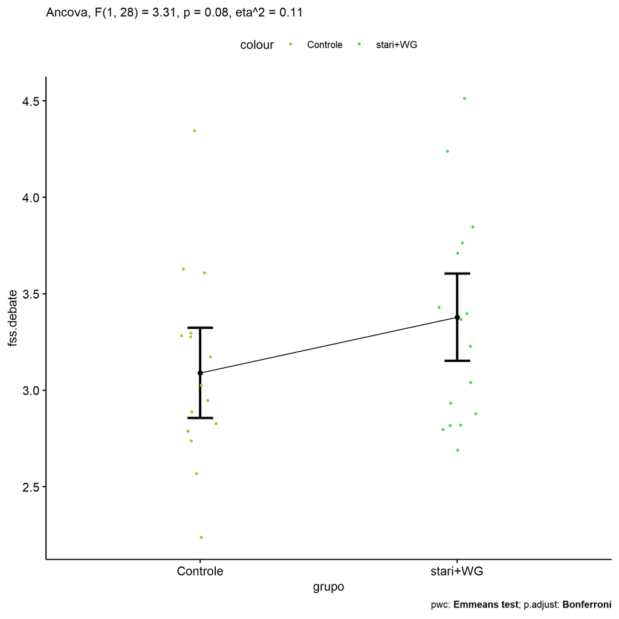

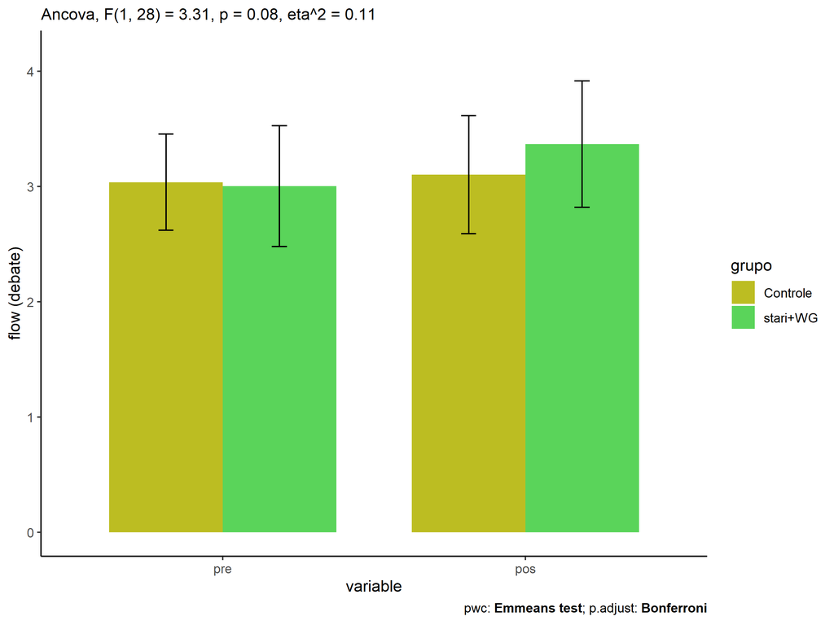

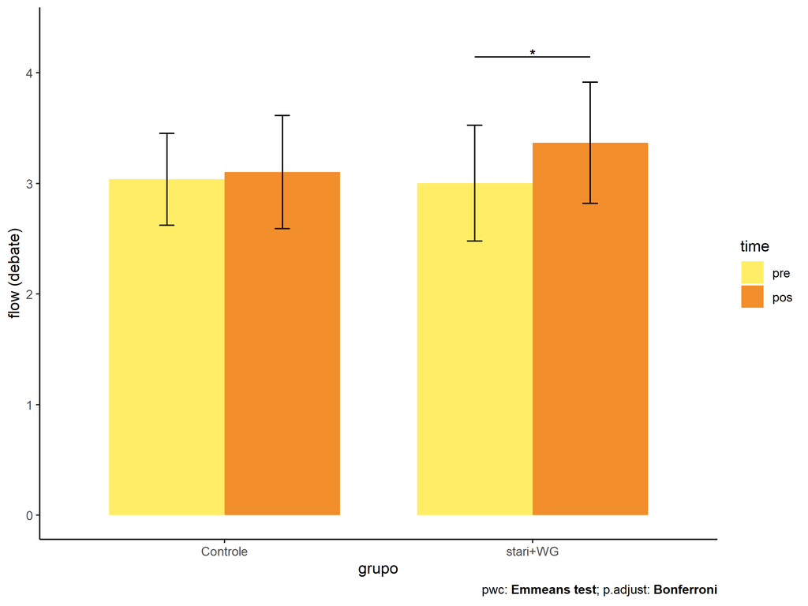

### factor: **genero**

| var | genero | n | M (pre) | SE (pre) | M (unadj) | SE (unadj) | M (adj) | SE (adj) |
| --- | --- | --- | --- | --- | --- | --- | --- | --- |
| fss.debate | F | 10 | 3.033 | 0.172 | 3.353 | 0.202 | 3.344 | 0.146 |
| fss.debate | M | 21 | 3.012 | 0.096 | 3.185 | 0.107 | 3.189 | 0.100 |

| .y. | group1 | group2 | estimate | conf.low | conf.high | se | statistic | p | p.adj | p.adj.signif |
| --- | --- | --- | --- | --- | --- | --- | --- | --- | --- | --- |
| fss.debate | F | M | 0.154 | -0.208 | 0.517 | 0.177 | 0.872 | 0.391 | 0.391 | ns |
| dfs.debate | F | M | 0.021 | -0.352 | 0.395 | 0.183 | 0.116 | 0.908 | 0.908 | ns |

| .y. | genero | group1 | group2 | estimate | conf.low | conf.high | se | statistic | p | p.adj | p.adj.signif |
| --- | --- | --- | --- | --- | --- | --- | --- | --- | --- | --- | --- |
| flow.debate | F | pre | pos | -0.319 | -0.776 | 0.137 | 0.228 | -1.401 | 0.167 | 0.167 | ns |
| flow.debate | M | pre | pos | -0.173 | -0.488 | 0.142 | 0.157 | -1.100 | 0.276 | 0.276 | ns |

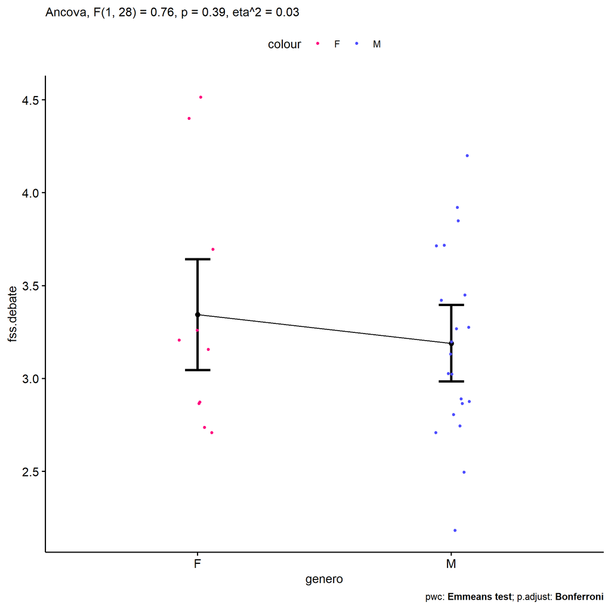

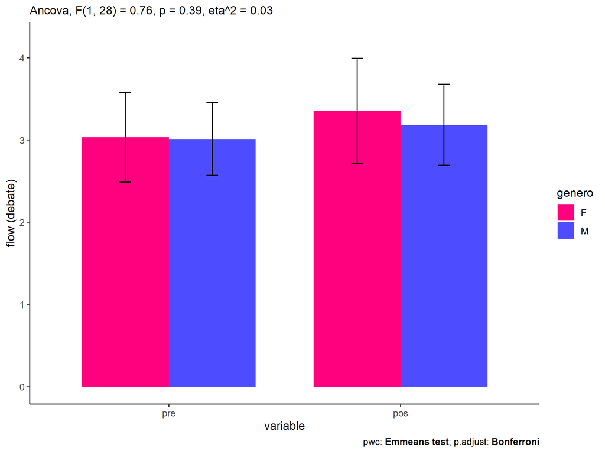

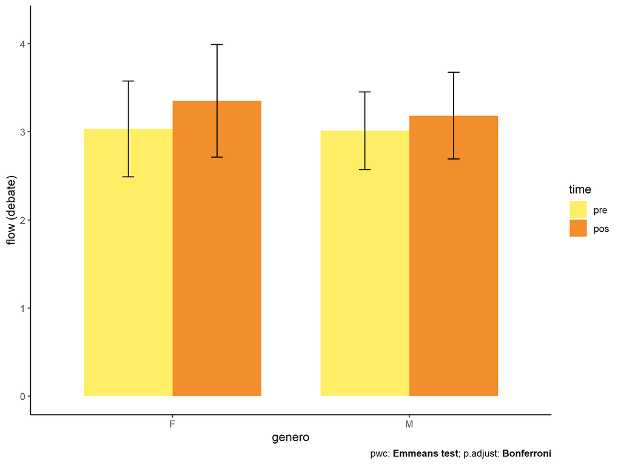

### factor: **idade**

| var | idade | n | M (pre) | SE (pre) | M (unadj) | SE (unadj) | M (adj) | SE (adj) |
| --- | --- | --- | --- | --- | --- | --- | --- | --- |
| fss.debate | 10y | 6 | 3.074 | 0.142 | 3.704 | 0.231 | 3.686 | 0.166 |
| fss.debate | 11y | 17 | 3.008 | 0.106 | 3.113 | 0.089 | 3.119 | 0.098 |

| .y. | group1 | group2 | estimate | conf.low | conf.high | se | statistic | p | p.adj | p.adj.signif |
| --- | --- | --- | --- | --- | --- | --- | --- | --- | --- | --- |
| fss.debate | 10y | 11y | 0.567 | 0.165 | 0.969 | 0.193 | 2.944 | 0.008 | 0.008 | ** |
| dfs.debate | 10y | 11y | 0.066 | -0.347 | 0.478 | 0.198 | 0.331 | 0.744 | 0.744 | ns |

| .y. | idade | group1 | group2 | estimate | conf.low | conf.high | se | statistic | p | p.adj | p.adj.signif |
| --- | --- | --- | --- | --- | --- | --- | --- | --- | --- | --- | --- |
| flow.debate | 10y | pre | pos | -0.630 | -1.120 | -0.140 | 0.243 | -2.594 | 0.013 | 0.013 | * |
| flow.debate | 11y | pre | pos | -0.104 | -0.395 | 0.187 | 0.144 | -0.724 | 0.473 | 0.473 | ns |

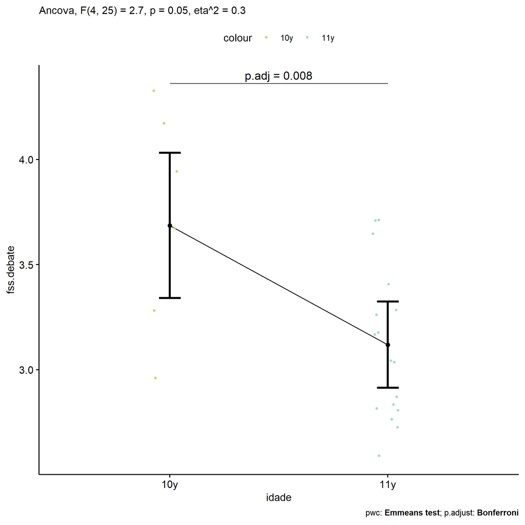

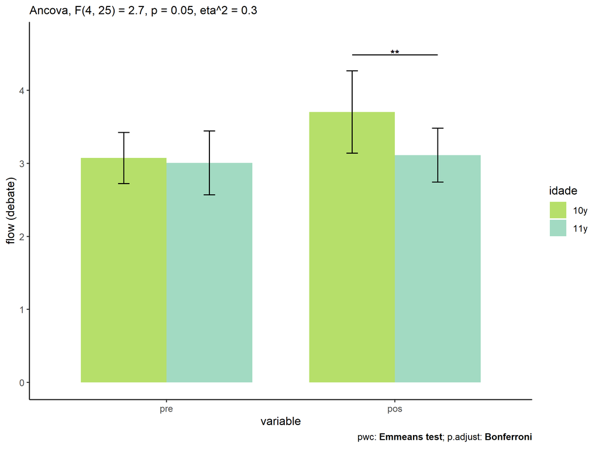

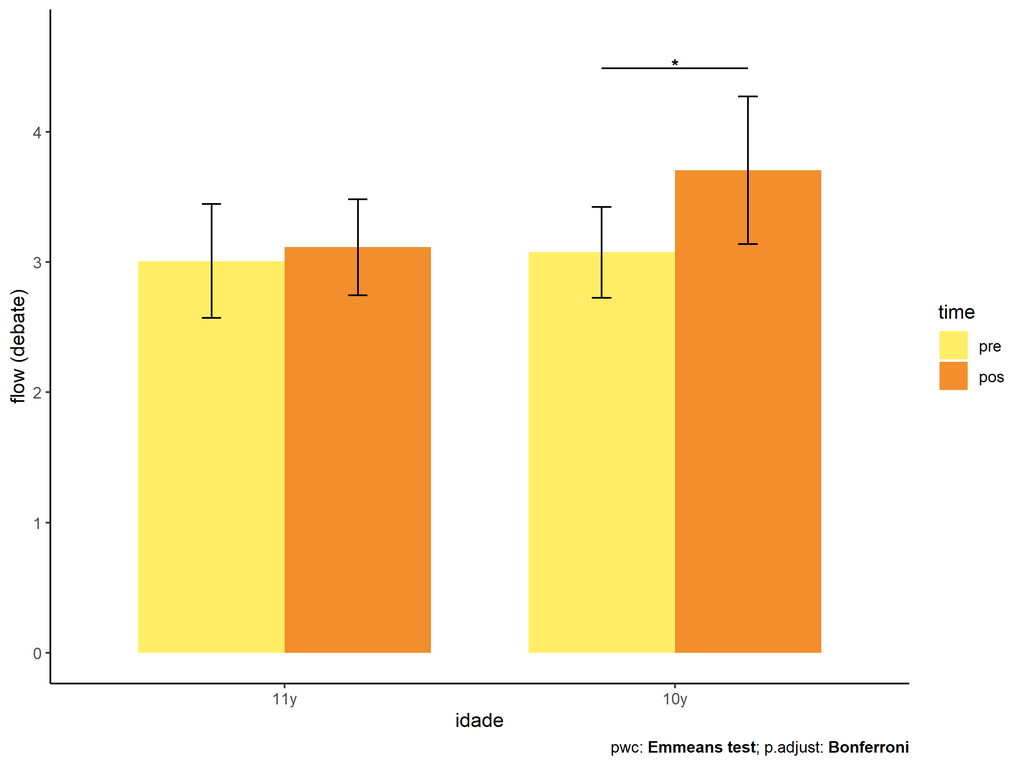

### factor: **zona.participante**

| var | zona.participante | n | M (pre) | SE (pre) | M (unadj) | SE (unadj) | M (adj) | SE (adj) |
| --- | --- | --- | --- | --- | --- | --- | --- | --- |
| fss.debate | Rural | 7 | 2.909 | 0.077 | 3.127 | 0.208 | 3.248 | 0.189 |
| fss.debate | Urbana | 15 | 3.148 | 0.138 | 3.311 | 0.155 | 3.255 | 0.127 |

| .y. | group1 | group2 | estimate | conf.low | conf.high | se | statistic | p | p.adj | p.adj.signif |
| --- | --- | --- | --- | --- | --- | --- | --- | --- | --- | --- |
| fss.debate | Urbana | Rural | 0.007 | -0.476 | 0.49 | 0.231 | 0.03 | 0.976 | 0.976 | ns |
| dfs.debate | Urbana | Rural | 0.239 | -0.202 | 0.68 | 0.211 | 1.13 | 0.272 | 0.272 | ns |

| .y. | zona.participante | group1 | group2 | estimate | conf.low | conf.high | se | statistic | p | p.adj | p.adj.signif |
| --- | --- | --- | --- | --- | --- | --- | --- | --- | --- | --- | --- |
| flow.debate | Urbana | pre | pos | -0.163 | -0.552 | 0.227 | 0.193 | -0.846 | 0.403 | 0.403 | ns |
| flow.debate | Rural | pre | pos | -0.218 | -0.788 | 0.352 | 0.282 | -0.772 | 0.445 | 0.445 | ns |

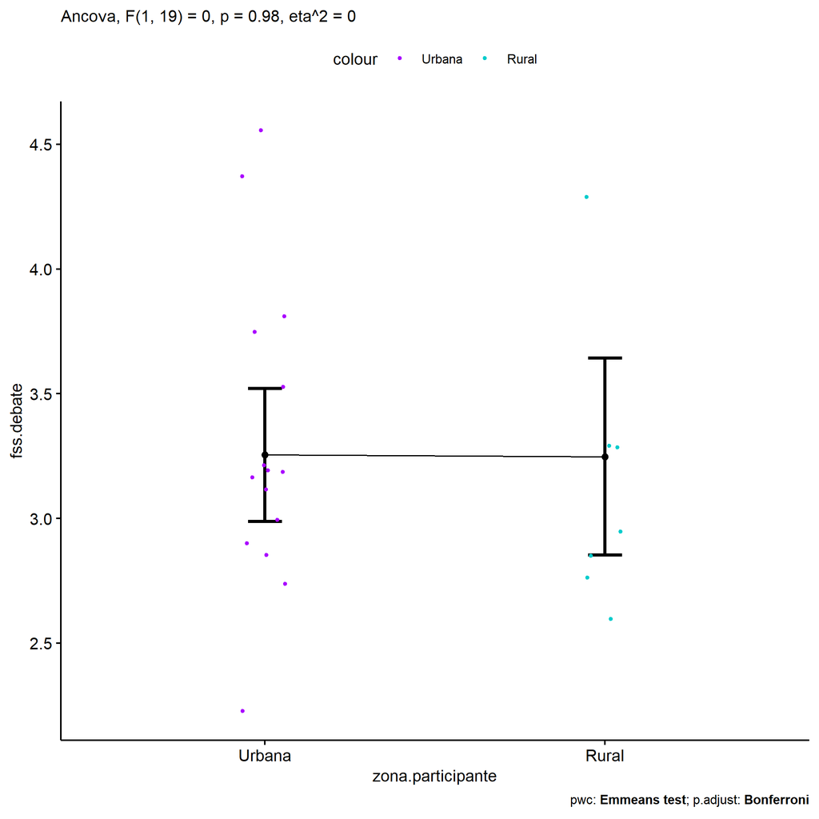

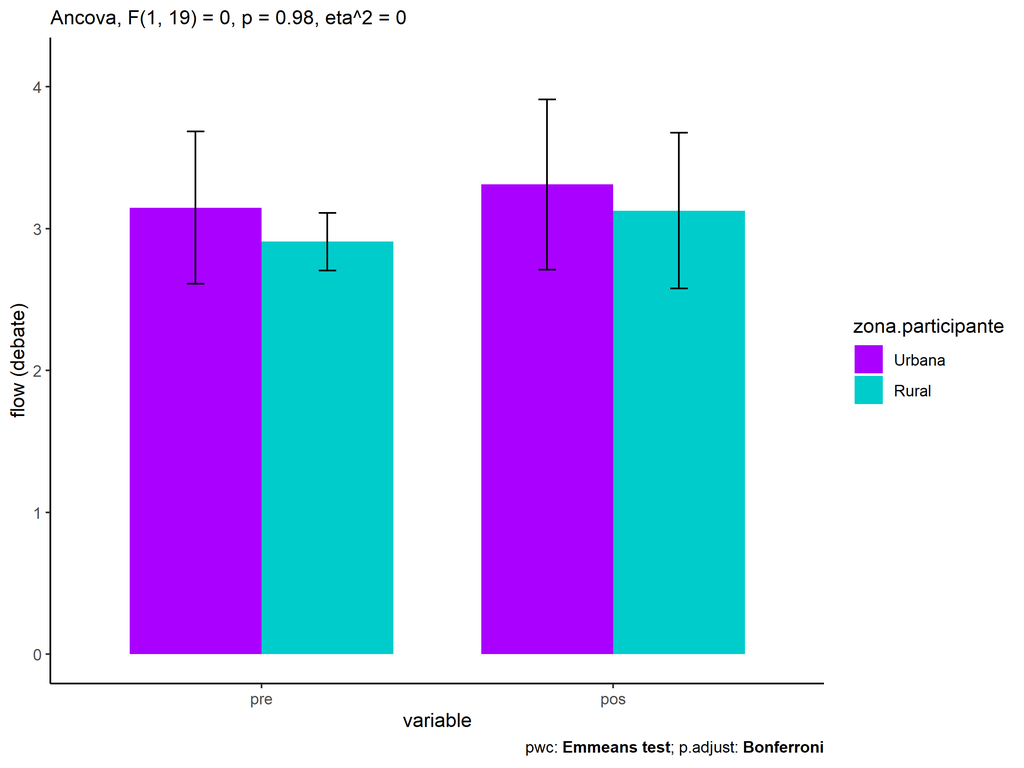

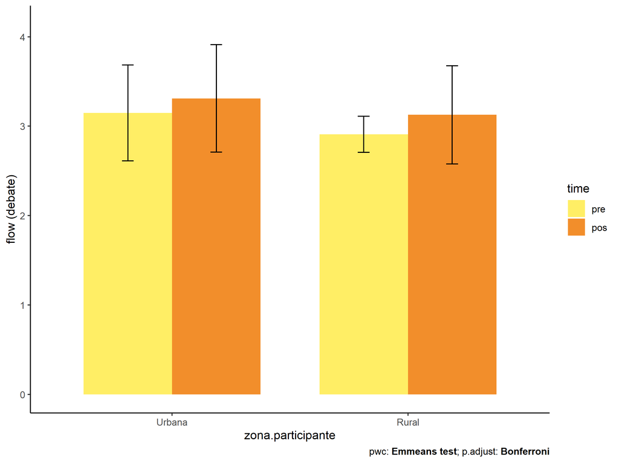

### factor: **escola**

| var | escola | n | M (pre) | SE (pre) | M (unadj) | SE (unadj) | M (adj) | SE (adj) |
| --- | --- | --- | --- | --- | --- | --- | --- | --- |
| fss.debate | E1 | 6 | 2.907 | 0.228 | 3.093 | 0.283 | 3.148 | 0.200 |
| fss.debate | E4 | 5 | 3.333 | 0.230 | 3.606 | 0.237 | 3.418 | 0.228 |
| fss.debate | E5 | 13 | 2.923 | 0.134 | 3.081 | 0.138 | 3.128 | 0.136 |

| .y. | group1 | group2 | estimate | conf.low | conf.high | se | statistic | p | p.adj | p.adj.signif |
| --- | --- | --- | --- | --- | --- | --- | --- | --- | --- | --- |
| fss.debate | E1 | E4 | -0.271 | -0.912 | 0.371 | 0.308 | -0.880 | 0.389 | 1.000 | ns |
| fss.debate | E1 | E5 | 0.020 | -0.480 | 0.521 | 0.240 | 0.085 | 0.933 | 1.000 | ns |
| fss.debate | E4 | E5 | 0.291 | -0.272 | 0.854 | 0.270 | 1.078 | 0.294 | 0.882 | ns |
| dfs.debate | E1 | E4 | -0.426 | -1.066 | 0.214 | 0.308 | -1.384 | 0.181 | 0.543 | ns |
| dfs.debate | E1 | E5 | -0.016 | -0.537 | 0.506 | 0.251 | -0.062 | 0.951 | 1.000 | ns |
| dfs.debate | E4 | E5 | 0.410 | -0.146 | 0.967 | 0.268 | 1.534 | 0.140 | 0.420 | ns |

| .y. | escola | group1 | group2 | estimate | conf.low | conf.high | se | statistic | p | p.adj | p.adj.signif |
| --- | --- | --- | --- | --- | --- | --- | --- | --- | --- | --- | --- |
| flow.debate | E1 | pre | pos | -0.185 | -0.806 | 0.435 | 0.307 | -0.602 | 0.550 | 0.550 | ns |
| flow.debate | E4 | pre | pos | -0.272 | -0.952 | 0.408 | 0.337 | -0.808 | 0.424 | 0.424 | ns |
| flow.debate | E5 | pre | pos | -0.158 | -0.580 | 0.263 | 0.209 | -0.757 | 0.453 | 0.453 | ns |

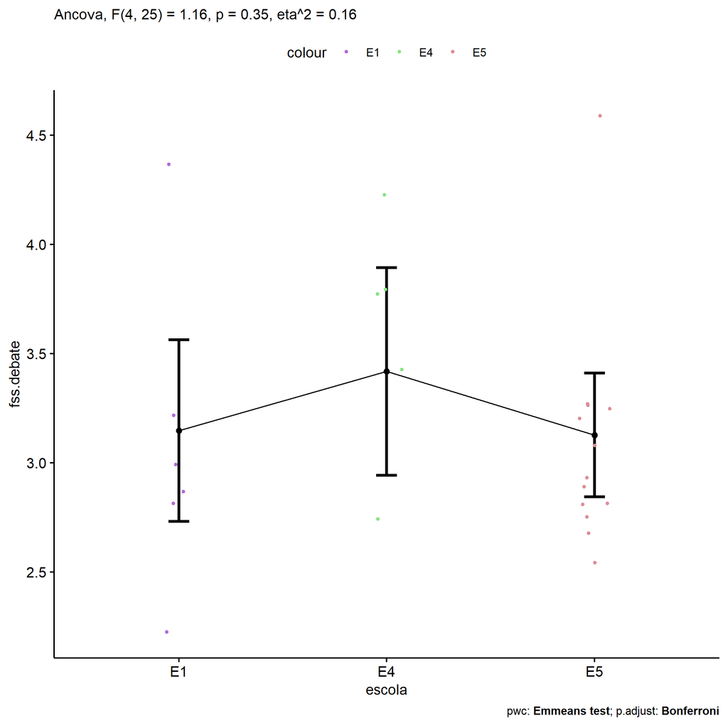

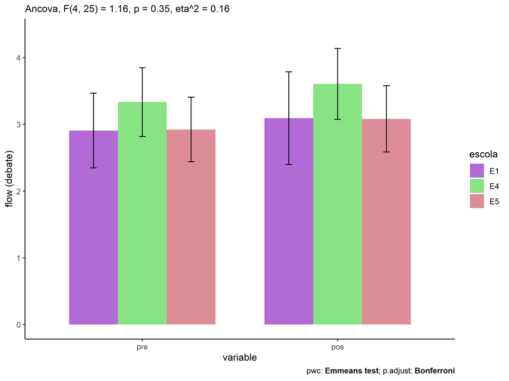

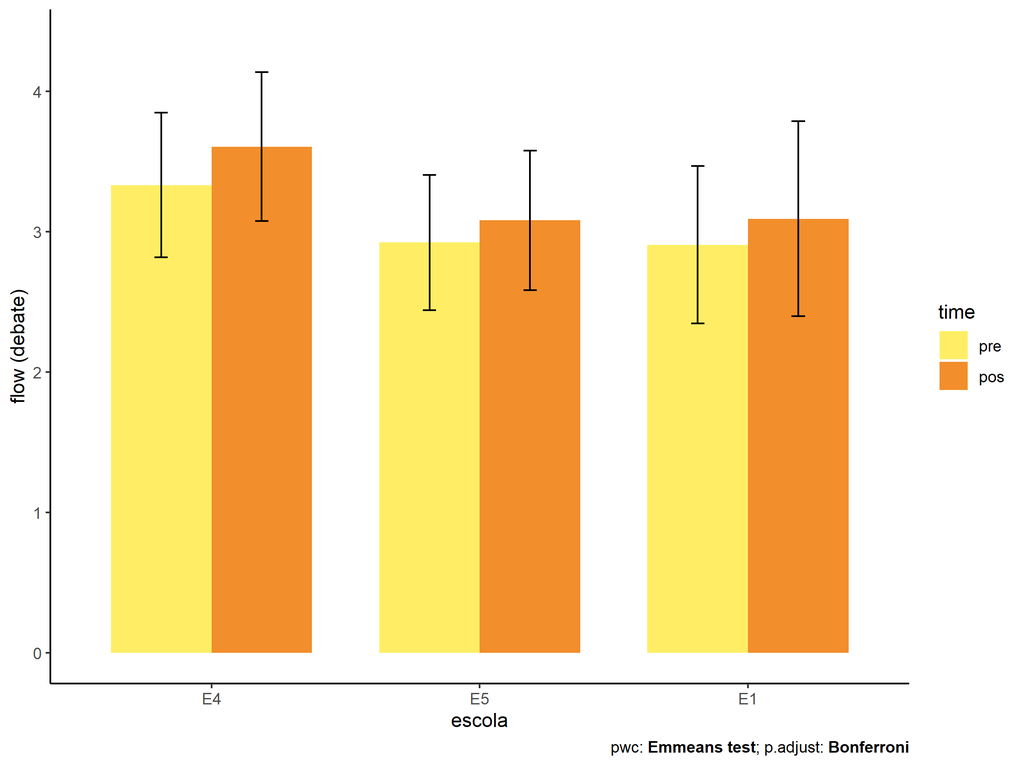